# The Exchange Rate Path Problem

## Introduction

This exercice deals with **The Exchange Rate Path Problem**.

We receive a serie of price updates:

**[timestamp] [exchange] [source_currency] [destination_currency] [forward_factor] [backward_factor]**

For instance:

**2017-11-01T09:42:23+00:00 KRAKEN BTC USD 1000.0 0.0009**

*Which means that **a price update was received** from Kraken on November 1, 2017 at 9:42 am. The update says **1 BTC = 1000 USD** and **1 USD = 0.0009 BTC***

Price updates are **not guaranteed** to arrive in chronological order so we have to consider only the most recent price update for each (source_currency, destination_currency) pair.

We have to store these data in a graph.

**Example:**  
We receive the following price_update stream:

2017-11-01T09:42:23+00:00 KRAKEN BTC USD 1000.0 0.0009  
2017-11-01T09:43:23+00:00 GDAX BTC USD 1001.0 0.0008

We have to create the following graph:

(KRAKEN, BTC) -- 1000.0 --> (KRAKEN, USD)  
(KRAKEN, USD) -- 0.0009 --> (KRAKEN, BTC)  
(GDAX, BTC) -- 1001.0 --> (GDAX, USD)  
(GDAX, USD) -- 0.0008 --> (GDAX, BTC)  
(KRAKEN, BTC) -- 1.0 --> (GDAX, BTC)  
(GDAX, BTC) -- 1.0 --> (KRAKEN, BTC)  
(KRAKEN, USD) -- 1.0 --> (GDAX, USD)  
(GDAX, USD) -- 1.0 --> (KRAKEN, USD)

Then we receive an exchange rate request

**EXCHANGE_RATE_REQUEST [source_exchange] [source_currency] [destination_exchange] [destination_currency]**

For instance:

**EXCHANGE_RATE_REQUEST KRAKEN BTC GDAX USD**

*With this rate_request, we have to return the **best possible exchange rate** as well as the **trades and transfers needed** to achieve that rate*

#### The main goal of this exercice is to create a program that can:

Manage the reception of price updates information  
Organize them in a graph  
Find the best rate for a trade between two pairs (ExchangeA, CurrencyA) / (ExchangeB, CurrencyB)

For this exercice, I decided to work using **Python 3** for several reasons:

- Diversity of libraries
- Popular language
- Possibility to easily generate explicative notebook
- Personal wish to improve my Python skills

With this notebook, I will try to explain how I thought and implemented the solution of this problem. It will be organized as follows:

1. Desciption of scenario
2. Presentation of architecture
3. Test of the code
4. Other example
5. Conclusion & comments

## Description of scenario

1. Reception of price_updates data on stdin
2. Creation of an oriented graph with the data received
3. Computation of the best_rates matrix
4. Reception of rate_request
5. Computation and output of the path

## Architecture

Three classes so as to discribe our situation: Vertex(), Edge(), Graph().

A graph is a **list of Edges**, an **edge** is **composed of two vertices.**

When we receive price_updates stream, we modify the list of edges and therefore, the graph.

#### Class Vertex()

```python
class Vertex(object):
    """ Vertex class to model a pair (exchange, currency) """

    def __init__(self,exchange,currency):
        """ Constructor
         Args:
             exchange (str): exchange name
             currency (str): ISO code of a currency
        """

        if not isinstance(exchange, str):
            raise TypeError("'exchange' information not correct!") # exchange input must be a string
        if  not isinstance(currency, str):
            raise TypeError("'currency' information not correct!") # currency input must be a string
        else:
            self.__exchange = exchange.upper() # value of exchange in UPPER case
            self.__currency = currency.upper() # value of currency in UPPER case

    @property
    def exchange(self):
        """ Get exchange property """
        return self.__exchange

    @property
    def currency(self):
        """ Get currency property """
        return self.__currency

    def __str__(self):
        """ Formatting of print option for a vertex """
        return "%s, %s" % (self.exchange,self.currency)

    def __eq__(self,other):
        """ Overloading of operator == so as to enable the comparison between two vertices"""
        if not isinstance(other, Vertex):
            raise TypeError("other must be a Vertex")
        if self.exchange == other.exchange and self.currency == other.currency:
            return True
        else:
            return False
```

#### Class Edge()

```python
class Edge():
    """ Edge class to model an edge:  <vertex_source> <vertex_destination> <weight> <date> """

    def __init__(self,vertex_source, vertex_destination, weight, date):
        """ Constructor
        Args:
            vertex_source: source vertex of the edge
            vertex_destination: destination vertex of the edge
            weight: weight of the edge, represent the rate between two vertex
            date: date of last update of the edge information
        """
        # We test the type of each input
        if not isinstance(vertex_source, Vertex):
            raise TypeError("'vertex_source' must be a Vertex")
        if not isinstance(vertex_destination, Vertex):
            raise TypeError("'vertex_destination' must be a Vertex")
        if not isinstance(weight, int) and not isinstance(weight, float):
            raise TypeError("'weight' must be a numeric value")
        if not isinstance(parser.parse(date), datetime): # The date parameter must be parsable into datetime object
            raise TypeError("Date format incorrect")
        else:
            self.__vertex_source = vertex_source
            self.__vertex_destination = vertex_destination
            self.__weight = weight
            self.__date = parser.parse(date) # Date parameter converted as datetime object

    @property
    def vertex_source(self):
        """ Get vertex_source property """
        return self.__vertex_source

    @property
    def vertex_destination(self):
        """ Get vertex_destination property """
        return self.__vertex_destination

    @property
    def weight(self):
        """ Get weight property """
        return self.__weight

    @property
    def date(self):
        """ Get date property """
        return self.__date

    @weight.setter
    def weight(self, value):
        """ Set weight property, with parameter 'value' which must be an int or a float """
        if not isinstance(value, int) and not isinstance(value, float):
            raise TypeError("'weight' must be a numeric value")
        else:
            self.__weight = value

    @date.setter
    def date(self,value):
        """ Set date property with parameter 'value' which must be convertible into a datetime object """
        try:
            date = parser.parse(value)
            self.__date=date
        except:
            raise ValueError("Date format incorrect")

    def __str__(self):
        """" Formatting of print option for an edge """
        return "%s (%s) ---- %s ---> (%s)" % (str(self.date), self.vertex_source, str(self.weight), self.vertex_destination)
```

#### Class Graph()

The **main class** of the program. It allows to store, compute and manage all information of the graph. When we add or update information on the graph, all tests and verifications are performed within this class.

NB: The **compute_best_rate_matrix()** is the most interesting function of this class. Indeed it uses the modified Floyd Marshall algoithm with several interesting modifications which allow us to use this algorithm in our situation

```python
class Graph(object):
    """ Main class of this project: allows to store and compute all information of a graph

    Args:
        list_vertices: list of all vertices of the graph
        list_edges: list of all edges of the graph
        rates: matrix representation of weight between edges of the graph
        next: transition matrix
    """

    def __init__(self):
        """ Default constructor, no parameter needed to create a graph
        The graph will be modify after reception of prices_update stream """
        self.__list_vertices = []
        self.__list_edges = []
        self.__rates = [[]]
        self.__next = [[]]

    @property
    def list_vertices(self):
        """ Get list_vertices parameter """
        return self.__list_vertices

    @property
    def list_edges(self):
        """ Get list_edges parameter """
        return self.__list_edges

    @property
    def rates(self):
        """ Get rates parameter """
        return self.__rates

    @property
    def next(self):
        """ Get next parameter """
        return self.__next

    def __str__(self):
        """" Formatting of print option for a graph: we print all edges information """
        return ''.join([str(edge) + '\n' for edge in self.list_edges])



    def add_price_updates(self, stream_price_updates):
        """ Procedure which allow to update the graph with the last prices information received """

        # A stream of price_updates can contain several updates
        for price_update in stream_price_updates:
            data = price_update.split()

            # Creation of two edges with the data provided in the price_update stream:
            # Edge(vertex_a, vertex_b, weight_from_a_b, date) and Edge(vertex_b, vertex_a, weight_from_b_a, date)
            try:
                e1, e2 = Edge(Vertex(data[1], data[2]), Vertex(data[1], data[3]), float(data[4]), data[0]), \
                         Edge(Vertex(data[1], data[3]), Vertex(data[1], data[2]), float(data[5]), data[0])
            except Exception:
                print("Error input data: price_update stream incorrect -> ", price_update, " -> error in this stream")
                continue

            # if not (e2.weight <= 1 and e2.weight >= 1/e1.weight):
            #     raise ValueError("The input price_update is not correct!")

            # For these two edges created, before we add them to the graph, we have to check if they don't already
            # exist in it. We don't do this verification by comparing the edge objects between them, because even if
            # there is already an edge corresponding to a couple (vertex_a, vertex_b), the date property of the edge
            # in the graph will be different from the date of the new edge created with last weight value
            if self.couple_vertex_exist(e1.vertex_source, e1.vertex_destination) == -1:
                # There is no edge in the graph between the couple (vertex_a, vertex_b) so we add the new edge to the graph
                self.add_edge(e1)
            elif e1.date > self.list_edges[self.couple_vertex_exist(e1.vertex_source, e1.vertex_destination)].date:
                # The couple of vertices (vertex_a, vertex_b) exists, so we have to compare the date of the old edge
                # already in the graph with the date of the new edge created with the data from price_update,
                # if the condition is satisfied, we modify the  edge in the graph with new weight value,
                # and we update the date of the edge
                self.list_edges[self.couple_vertex_exist(e1.vertex_source, e1.vertex_destination)].weight = float(
                    e1.weight)
                self.list_edges[self.couple_vertex_exist(e1.vertex_source, e1.vertex_destination)].date = str(e1.date)
            if self.couple_vertex_exist(e2.vertex_source, e2.vertex_destination) == -1:  # same test for second edge
                self.add_edge(e2)
            elif e2.date > self.list_edges[self.couple_vertex_exist(e2.vertex_source, e2.vertex_destination)].date:
                self.list_edges[self.couple_vertex_exist(e2.vertex_source, e2.vertex_destination)].weight = e2.weight
                self.list_edges[self.couple_vertex_exist(e2.vertex_source, e2.vertex_destination)].date = str(e2.date)

            # Now, we have to check if we have to create or not an edge between the two vertices with same currency
            # but different exchanges
            self.add_new_edge_same_currency_different_exchanges(e1.vertex_source)
            self.add_new_edge_same_currency_different_exchanges(e2.vertex_source)

            # The update of the graph is done so we can compute the best rates matrix using
            # the modified Floyd Warshall algorithm
        self.compute_best_rates_matrix()

    def add_edge(self, edge):
        """ Procedure which allows to add an edge on the graph and to add the corresponding vertices to the list_vertices
        attribute of the graph """
        self.__list_edges.append(edge)
        try:  # We check if the vertices we want to add are not already stored in our list of vertices
            self.__list_vertices.index(edge.vertex_source)
        except:
            self.__list_vertices.append(edge.vertex_source)

    def couple_vertex_exist(self, u, v):
        """ Function which allows to find the position of an edge composed by two vertices 'u' and 'v' in the list_edges
            of the graph:
                return -1 if there is no existing edge between (v1, v2) in the graph
                return the position of the edge in the list of all edges if an edge between v1 -> v2 exists """
        i = 0
        for e in self.list_edges:
            if e.vertex_source == u and e.vertex_destination == v:
                return i
            i += 1
        return -1

    def add_new_edge_same_currency_different_exchanges(self, vertex):
        """ Procedure which allows to add an edge between two vertices with identical currencies but different exchanges """

        # Before adding a new edge, we check if this edge already exists or not
        # We get all indexes of edges from the list_edges which have the same currency attribute as the vertex currency
        # attribut passed as a parameter
        tab_index = self.find_edge_same_currency_different_exchanges(vertex)
        for i in tab_index:
            # For each edge in list_edges at the position i, we check if an edge between the vertex we test and
            # the vertex_source of the edges at the position i in the list_edges already exists or not.
            # If the condition is not satisfied, we create two new edges with same currency and different exchanges
            if self.couple_vertex_exist(vertex, self.list_edges[i].vertex_source) == -1 and \
                            self.couple_vertex_exist(self.list_edges[i].vertex_source, vertex) == -1:
                self.list_edges.append(
                    Edge(vertex, self.list_edges[i].vertex_source, 1.0, str(datetime.now())))
                self.list_edges.append(
                    Edge(self.list_edges[i].vertex_source, vertex, 1.0, str(datetime.now())))

    def find_edge_same_currency_different_exchanges(self, vertex):
        """ Function which allows to get a list of index of edges from the list_edges, which have the same currency
            but a different exchange, compared to the vertex passed as a parameter
            We use this function to get all edges positions from the list_edges which vertex_source currency attribute
            is the same as the currency of the vertex passed as a parameter """

        list_index, i = [], 0
        for edge in self.list_edges:
            if edge.vertex_source.currency == vertex.currency and edge.vertex_source.exchange != vertex.exchange:
                list_index.append(i)
            i += 1
        return list_index



    def compute_best_rates_matrix(self):
        """ Function which allows to compute the best rates matrix
            This procedure is a modified version of the Floyd Warshall algorithm.
         """

        # Creation of two empty matrices
        rates = [[0 for i in range(len(self.list_vertices))] for j in range(len(self.list_vertices))]
        next = [[None for i in range(len(self.list_vertices))] for j in range(len(self.list_vertices))]

        # Now, we want to complete rates matrice with the weights of the edges.
        # However, the Floyd Warshall algorithm can run only if the weights w are between 0 and 1
        # So we have to normalize the weight of edges!
        # To do so, we use the formula w'=(w-Wmin)/(Wmax-Wmin)
        # w': normalized weight
        # w: normal weight
        # Wmin: min weight among all edges weight, Wmax: max weight among all edges weight

        all_weights= [edge.weight for edge in self.list_edges] #get all weights of edges
        min_rate = min(all_weights) # get minimum weight
        max_rate=max(all_weights)# get maximum weight

        # We complete the two matrices with data from the list of edges
        i, j = 0, 0
        for i in range(0, len(rates[0])):
            for j in range(0, len(rates[0])):
                if isinstance(self.get_edge_from_couple_vertices(self.list_vertices[i], self.list_vertices[j]), Edge):
                    w = self.get_edge_from_couple_vertices(self.list_vertices[i], self.list_vertices[j]).weight
                    if w == 1:
                        rates[i][j]=1.0
                    elif w == 0:
                        rates[i][j]=0
                    else:
                        rates[i][j] = (w - min_rate) / (max_rate - min_rate) #weight normalization
                    next[i][j] = next[i][j] = self.get_edge_from_couple_vertices(self.list_vertices[i], self.list_vertices[j]).vertex_destination
                else:
                    rates[i][j] =0
                    next[i][j] = None

        # We compute the best rates matrix and the next matrix thanks to the modified Floyd Warshall algorithm
        for k in range(0, len(self.list_vertices)):
            for i in range(0, len(self.list_vertices)):
                for j in range(0, len(self.list_vertices)):
                    if rates[i][j] < rates[i][k] * rates[k][j]:
                        rates[i][j] = rates[i][k] * rates[k][j]
                        next[i][j] = next[i][k]

        self.__rates = rates
        self.__next = next

    def get_edge_from_couple_vertices(self, v1, v2):
        """ Function which returns the edge corresponding to the couple of vertices (v1, v2) """

        for e in self.list_edges:
            if e.vertex_source == v1 and e.vertex_destination == v2:
                return e
        return None

    def find_best_path(self, u, v):
        """ Function which allows to browse the next matrix so as to rebuilt the path from vertex u to vertex v """

        if self.next[self.list_vertices.index(u)][self.list_vertices.index(v)] is None:
            return []
        path = []
        path.append(u)
        while u != v:
            u = self.next[self.list_vertices.index(u)][self.list_vertices.index(v)]
            path.append(u)

        return path

    def compute_best_rate_from_best_path(self, best_path):

        """ Function which allow to compute the best rate """
        best_rate=1
        for i in range(0, len(best_path)-1):
            best_rate *= self.get_edge_from_couple_vertices(best_path[i],best_path[i+1]).weight
        return best_rate
```

#### Some other functions

```python
def input_rate_request(graph):
    """ Function to enter input rate_request on stdin
        The request must be as follows: <source_exchange> <source_currency> <destination_exchange> <destination_currency>"""

    while True:
        try:
            rate_request = "ECHANGE_RATE_REQUEST "+input("Type your exchange rate request: EXCHANCE_RATE_REQUEST ")
            graph.list_vertices.index(Vertex(rate_request.split(" ")[1], rate_request.split(" ")[2]))
            graph.list_vertices.index(Vertex(rate_request.split(" ")[3], rate_request.split(" ")[4]))
            u = Vertex(rate_request.split(" ")[1], rate_request.split(" ")[2])
            v = Vertex(rate_request.split(" ")[3], rate_request.split(" ")[4])
            break
        except ValueError:
            print("Error: Input incorrect, pairs ('exchange' 'currency') must exist in the graph, try an other request!!!!")
        except IndexError:
            print("Error: Incomplete request, try an other one!! \nFormat: <source_exchange> <source_currency> "
                                                                    "<destination_exchange> <destination_currency>")
        except Exception:
            print("Error: Try an other request")
    return (u,v)

def output_formatting(path, best_rate):
    """ Function which allows to display the result of the exchange rate request """

    if path:
        return "BEST_RATES_BEGIN " + \
                 path[0].exchange + " " + \
                 path[0].currency + " " + \
                 path[-1].exchange + " " + \
                 path[-1].currency + " " + \
                 str(best_rate) + '\n' + \
                 ''.join([str(vertex)+'\n' for vertex in path]) + \
                 "BEST_RATES_END"
    else:
        return "NO PATH FOUND"



def draw_graph(data, best_path=[], best_rate=None, node_size=1500, node_color='grey', node_alpha=0.5, node_text_size=5,
               edge_color='grey', edge_alpha=1, edge_tickness=2, edge_text_pos=0.8, text_font='sans-serif',
               edge_label_font_size=6):
    """ Procedure which allow to draw and plot the graph, using Networkx (creat a graph)and Matplotlib (plot) packages """

    # create Networkx graph
    G=nx.Graph()

    # get edges as couple(edge_A, edge_B)
    graph=[(str(data[i].vertex_source),str(data[i].vertex_destination)) for i in range(len(data))]
    # add edges to the graph
    for edge in graph:
        G.add_edge(edge[0], edge[1])

    # fix dispositon of the graph
    graph_pos=nx.shell_layout(G)

    #get weight data
    labels = [str(data[i].weight) for i in range(len(data))]
    edges_labels = dict(zip(graph, labels))

    # draw graph
    nx.draw_networkx_nodes(G,graph_pos,node_size=node_size, alpha=node_alpha, node_color=node_color) #nodes formatting
    nx.draw_networkx_edges(G, graph_pos, width=edge_tickness, alpha=edge_alpha, edge_color=edge_color) #edges formatting
    nx.draw_networkx_labels(G, graph_pos, font_size=node_text_size, font_family=text_font)#labels formatting
    nx.draw_networkx_edge_labels(G, graph_pos, edge_labels=edges_labels, font_size= edge_label_font_size,
                                                                        label_pos=edge_text_pos) #edges label (weight formatting)

    # if best_path and best_rate are not empty or null, change color of edges and nodes of best_path
    # Networkx needs edges information as list of couple (vertex_A, vertex_B) and nodes information as list of node
    if best_path and best_rate:
        nodes_best_path_in_G = [str(vertex) for vertex in best_path]
        edges_best_path_in_G = []
        for i in range(0, len(best_path)-1):
            edges_best_path_in_G.append( ( str(best_path[i]),str(best_path[i+1])))
        nodes_best_path_in_G.append(str(best_path[-1]))
        # change color of nodes of the best path
        nx.draw_networkx_nodes(G, graph_pos, nodelist=nodes_best_path_in_G, node_size=node_size,
                                                                            alpha=node_alpha, node_color='g')
        # change oolor of esges of the best path
        nx.draw_networkx_edges(G, graph_pos, edgelist= edges_best_path_in_G,  width=3,

                                                                            alpha=edge_alpha, edge_color='g')
        # add title
        plt.title("BEST RATE REQUEST "+str(best_path[0]).replace(',','') + " " +
                                       str(best_path[-1]).replace(',','') + ' ' +
                                       str(best_rate), fontsize=10, color = 'g')

    plt.axis('off') # don't show axis
    plt.show() # show the graph!
```

## Let's try this code

```python
from dateutil import parser
from datetime import datetime
import networkx as nx
import matplotlib.pyplot as plt
```

### Creation of the graph

```
List of all edges in the graph:

2017-11-01 09:42:23+00:00 (KRAKEN, BTC) ---- 1001.0 ---> (KRAKEN, USD)
2017-11-01 09:42:23+00:00 (KRAKEN, USD) ---- 0.0008 ---> (KRAKEN, BTC)
2017-11-01 09:43:23+00:00 (GDAX, BTC) ---- 1000.0 ---> (GDAX, USD)
2017-11-01 09:43:23+00:00 (GDAX, USD) ---- 0.0009 ---> (GDAX, BTC)
2018-11-10 22:03:37.959481 (GDAX, BTC) ---- 1.0 ---> (KRAKEN, BTC)
2018-11-10 22:03:37.959481 (KRAKEN, BTC) ---- 1.0 ---> (GDAX, BTC)
2018-11-10 22:03:37.959481 (GDAX, USD) ---- 1.0 ---> (KRAKEN, USD)
2018-11-10 22:03:37.959481 (KRAKEN, USD) ---- 1.0 ---> (GDAX, USD)
```

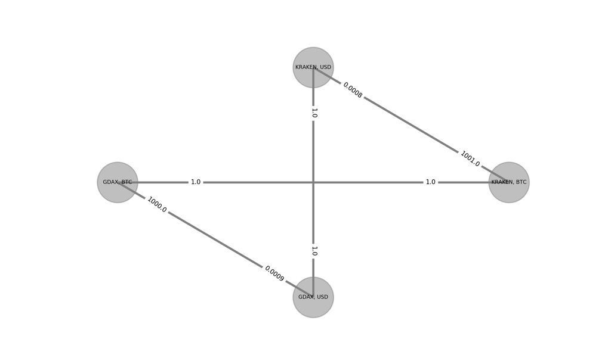

```python
%matplotlib notebook
# Creation of an empty graph
exchange_rate_graph = Graph()

# price_updates data stream received on stin
stream_price_updates = ["2017-11-01T09:42:23+00:00 KRAKEN BTC USD 1001.0 0.0008",
                        "2017-11-01T09:43:23+00:00 GDAX BTC USD 1000. 0.0009"]

# we add the prices_udpates on our graph
exchange_rate_graph.add_price_updates(stream_price_updates)

print("List of all edges in the graph:\n")
print(exchange_rate_graph)
draw_graph(exchange_rate_graph.list_edges)
```

### Update of the graph

##### Let's say that we receive a new stream of price_updates on stdin

```
List of all edges in the graph:

2018-11-03 09:42:23+00:00 (KRAKEN, BTC) ---- 1000.0 ---> (KRAKEN, USD)
2018-11-03 09:42:23+00:00 (KRAKEN, USD) ---- 0.0009 ---> (KRAKEN, BTC)
2018-11-03 09:43:23+00:00 (GDAX, BTC) ---- 1001.0 ---> (GDAX, USD)
2018-11-03 09:43:23+00:00 (GDAX, USD) ---- 0.0008 ---> (GDAX, BTC)
2018-11-10 22:03:37.959481 (GDAX, BTC) ---- 1.0 ---> (KRAKEN, BTC)
2018-11-10 22:03:37.959481 (KRAKEN, BTC) ---- 1.0 ---> (GDAX, BTC)
2018-11-10 22:03:37.959481 (GDAX, USD) ---- 1.0 ---> (KRAKEN, USD)
2018-11-10 22:03:37.959481 (KRAKEN, USD) ---- 1.0 ---> (GDAX, USD)
2018-11-03 09:43:23+00:00 (BITFINEX, BTC) ---- 1002.0 ---> (BITFINEX, USD)
2018-11-03 09:43:23+00:00 (BITFINEX, USD) ---- 0.0009 ---> (BITFINEX, BTC)
2018-11-10 22:03:50.723858 (BITFINEX, BTC) ---- 1.0 ---> (KRAKEN, BTC)
2018-11-10 22:03:50.723858 (KRAKEN, BTC) ---- 1.0 ---> (BITFINEX, BTC)
2018-11-10 22:03:50.723858 (BITFINEX, BTC) ---- 1.0 ---> (GDAX, BTC)
2018-11-10 22:03:50.724855 (GDAX, BTC) ---- 1.0 ---> (BITFINEX, BTC)
2018-11-10 22:03:50.724855 (BITFINEX, USD) ---- 1.0 ---> (KRAKEN, USD)
2018-11-10 22:03:50.724855 (KRAKEN, USD) ---- 1.0 ---> (BITFINEX, USD)
2018-11-10 22:03:50.724855 (BITFINEX, USD) ---- 1.0 ---> (GDAX, USD)
2018-11-10 22:03:50.724855 (GDAX, USD) ---- 1.0 ---> (BITFINEX, USD)
2018-11-03 09:43:23+00:00 (BITTREX, ETH) ---- 190.0 ---> (BITTREX, EUR)
2018-11-03 09:43:23+00:00 (BITTREX, EUR) ---- 0.004 ---> (BITTREX, ETH)
```

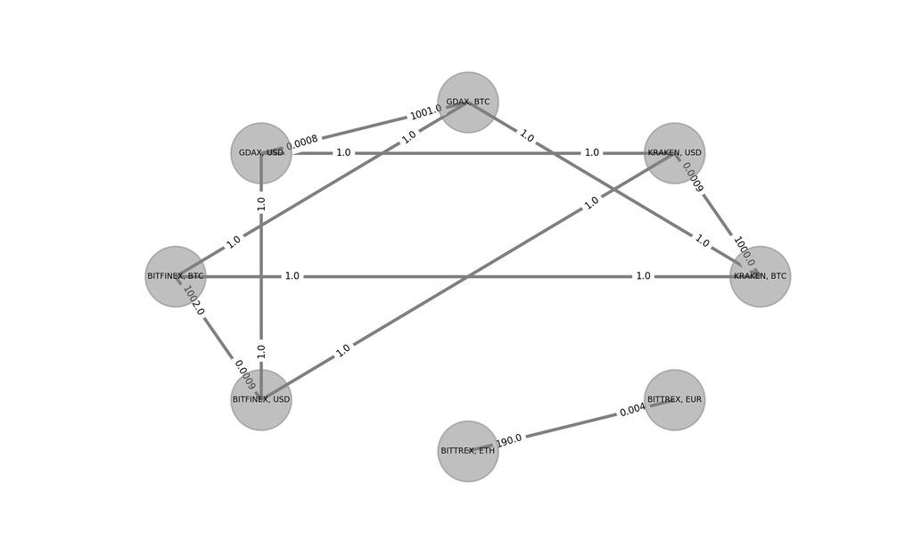

```python
%matplotlib notebook
# new price_updates data stream received on stin
stream_price_updates = ["2018-11-03T09:42:23+00:00 KRAKEN BTC USD 1000.0 0.0009",
                        "2018-11-03T09:43:23+00:00 GDAX BTC USD 1001.0 0.0008",
                        "2018-11-03T09:43:23+00:00 BITFINEX BTC USD 1002.0 0.0009",
                        "2018-11-03T09:43:23+00:00 BITTREX ETH EUR 190.0 0.004"]

# we add the price_udpates on our graph
exchange_rate_graph.add_price_updates(stream_price_updates)

print("List of all edges in the graph:\n")
print(exchange_rate_graph)
draw_graph(exchange_rate_graph.list_edges)
```

We have now a graph updated with the last data received on stdin

### Find the best rate

##### Let's say that we receive a new rate_request on stdin

```
BEST_RATES_BEGIN GDAX BTC KRAKEN USD 1002.0
GDAX, BTC
BITFINEX, BTC
BITFINEX, USD
KRAKEN, USD
BEST_RATES_END
```

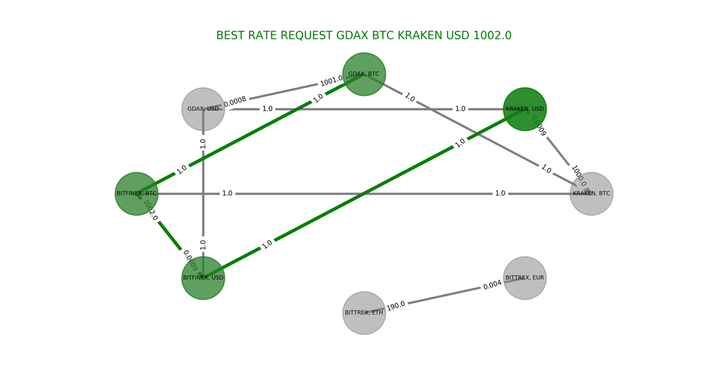

```python
%matplotlib notebook
# rate_request received on stin
rate_request = "EXCHANGE_RATE_REQUEST GDAX BTC KRAKEN USD"
vertex_source = Vertex(rate_request.split(' ')[1],rate_request.split(' ')[2])
vertex_destination = Vertex(rate_request.split(' ')[3],rate_request.split(' ')[4])

best_path = exchange_rate_graph.find_best_path(vertex_source, vertex_destination) # best path computation
best_rate = exchange_rate_graph.compute_best_rate_from_best_path(best_path) # best rate computation

print(output_formatting(best_path,  best_rate)) # print result on stdout
draw_graph(exchange_rate_graph.list_edges,best_path, best_rate) #draw graph with result
```

**The output gives us the best rate for the rate request GDAX BTC KRAKEN USD and which path we have to take!**

## Other example: new price_updates + new rate_request

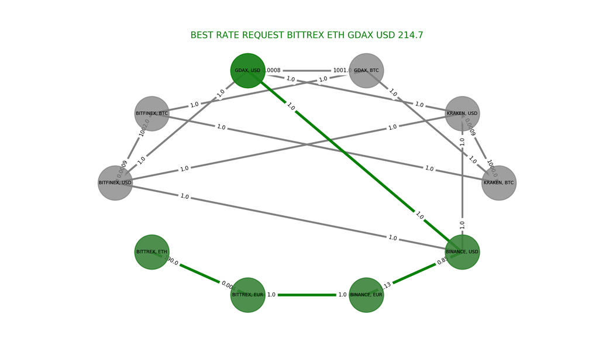

```
BEST_RATES_BEGIN BITTREX ETH GDAX USD 214.7
BITTREX, ETH
BITTREX, EUR
BINANCE, EUR
BINANCE, USD
GDAX, USD
BEST_RATES_END
```

```python
%matplotlib notebook
# new price_updates stream received on stin
stream_price_updates = ["2018-11-07T05:20:23+00:00 BINANCE EUR USD 1.13 0.85"]

# we add the price_udpates on our graph
exchange_rate_graph.add_price_updates(stream_price_updates)
draw_graph(exchange_rate_graph.list_edges)

#new rate_request received on stdin
rate_request = "EXCHANGE_RATE_REQUEST BITTREX ETH GDAX USD"

vertex_source = Vertex(rate_request.split(' ')[1],rate_request.split(' ')[2])
vertex_destination = Vertex(rate_request.split(' ')[3],rate_request.split(' ')[4])

best_path = exchange_rate_graph.find_best_path(vertex_source, vertex_destination) # best path computation
best_rate = exchange_rate_graph.compute_best_rate_from_best_path(best_path) # best rate computation

print(output_formatting(best_path,  best_rate)) # print result on stdout
draw_graph(exchange_rate_graph.list_edges,best_path, best_rate) #draw graph with result
```

## Conclution & comments

For this exercice, I decided to create my own Graph() class. Python provides a Graph() class with the library **Networkx** which is very uselful. Thanks to it, I could for instance plot my graph and have a nice way to illustrate my work.

I think it could be interesting to choose to work using the Networkx Graph() class because it provides a lot of functions to work on a graph. However, for this exercice, we don't need a lot of functions, we want to create a graph and to manage its edges so I decided to create my own class to produce a personal solution.